# Single-cell RNAseq Workshop

QC and Filtering with Seurat

Robert Fillinger

Single-cell genomics workshop · Day 2

October 21, 2026

## Last time

- HPC introduction
- How single cell data is acquired
- Got acquainted with single-cell data

## We’ll continue where we left off

- Open https://ondemand3.vai.zone/pun/sys/dashboard and choose the RStudio app.
- Choose RStudio version 2026-01-31-392.
- From the R version dropdown, choose bbc2/R/alt/R-4.6.0-setR_LIBS_USER (this is important!).
- Set the run time as needed (e.g., 4 hours).
- Set #CPU: 8 and Memory: 64, then click Launch.
- When your job is ready, click Connect to RStudio Server. You are now in RStudio.
- In RStudio, go to the Terminal tab and type:

`mkdir /varidata/researchtemp/hpctmp/first.lastname/`

- Replace “first.lastname” with your own name, with no spaces.

`/varidata/researchtemp/hpctmp/single_cell_workshop_2026/day2/presentations`

## This time: Quality Control and Filtration

- Number of unique genes in samples
- Cell counts per sample
- Ribosomal read counts
- Mitochondrial read counts
- Doublet cells

## Libraries and single-cell data

- Load in the libraries (or install them)
- Read in our data from day 1 with the readRDS function

```r
# BiocManager::install(c("Seurat","SeuratWrappers", "scDblFinder") )

library(Seurat)
library(SeuratWrappers)
library(scDblFinder)

seu = readRDS("/varidata/researchtemp/hpctmp/single_cell_workshop_2026/day1/data/raw_seu.Rds")
```

## Number of cells

- Cell quality and quantity are important.
- The first step is to make sure there are enough cells in each sample.

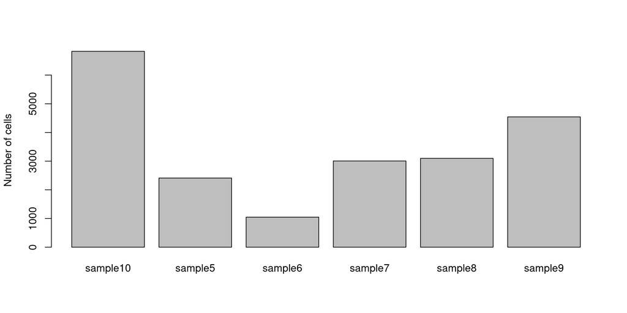

```r
barplot(table(seu@meta.data$orig.ident), ylab = "Number of cells") # Number of cells for each sample
```

## Number of cells

- Sample 6 looks pretty low compared to other cells.
- *Ideally*, you want >2000 cells, but lower cell counts can still work.

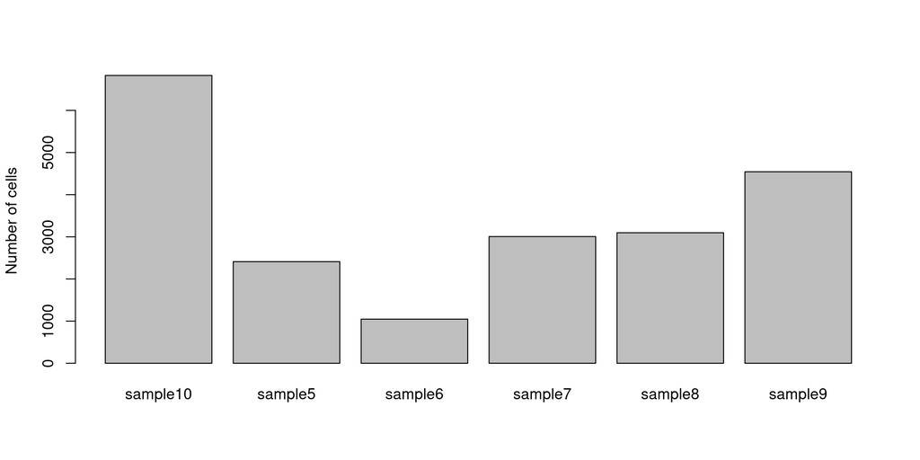

```r
barplot(table(seu@meta.data$orig.ident), ylab = "Number of cells") # Number of cells for each sample
```

## Looking at the number of features

- Feature count gives an idea of how many unique genes a sample’s cells have transcribed.
- This is **not** the number of reads.
- Samples 5 and 6 have a lot of features! They’re different, but that might make sense for your experiment.

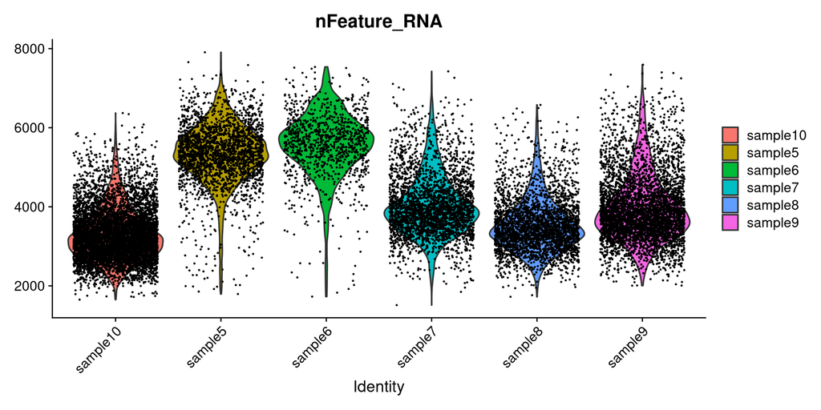

```r
VlnPlot(seu, features = "nFeature_RNA") # Number of unique transcribed RNA features
```

## Number of RNA reads in a cell

This *is* the number of reads in a cell.

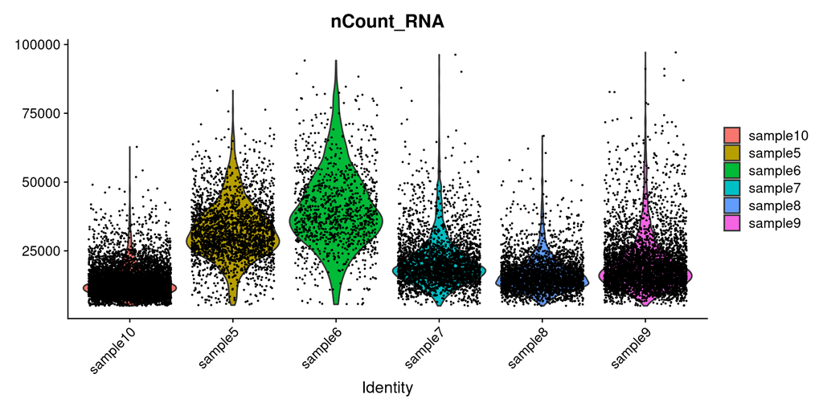

```r
VlnPlot(seu, features = "nCount_RNA") # Number of reads in each cell
```

## Finding cell ribosomal reads

- High ribosomal reads can indicate cell damage
- scRNA libraries often don’t pick up rRNA

```r
head(rownames(seu)[grepl("^Rp[sl]", rownames(seu))], n = 40)
```

```
 [1] "Rpl7"    "Rpl31"   "Rpl37a"  "Rps6kc1" "Rpl7a"   "Rpl12"   "Rpl35"
 [8] "Rps21"   "Rpl39"   "Rpl10"   "Rps4x"   "Rps6ka6" "Rpl36a"  "Rps6ka3"
[15] "Rpl22l1" "Rps3a1"  "Rps27"   "Rpl34"   "Rps20"   "Rps6"    "Rps8"
[22] "Rps6ka1" "Rpl11"   "Rpl22"   "Rpl9"    "Rpl5"    "Rplp0"   "Rpl6"
[29] "Rpl21"   "Rpl32"   "Rps9"    "Rpl28"   "Rps5"    "Rps19"   "Rps16"
[36] "Rps11"   "Rpl13a"  "Rpl18"   "Rps17"   "Rps3"
```

```r
seu <- PercentageFeatureSet(seu, pattern = "^Rp[sl]", col.name = "percent_ribo")
```

## Looking at ribosomal content of cells

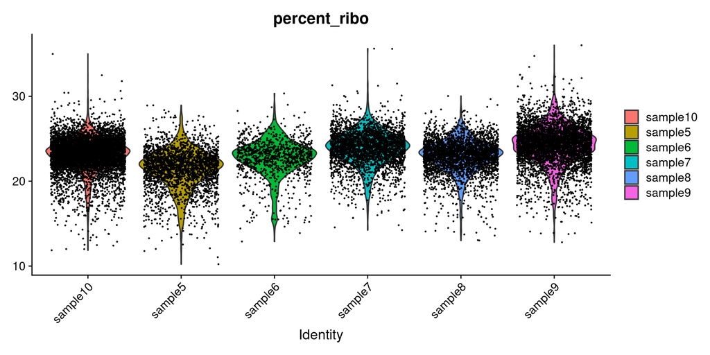

```r
VlnPlot(seu, features = "percent_ribo")
```

## Combining read and feature count

- Each dot is an individual cell, colored by sample
- “0.91” is the Pearson correlation relating RNA counts to features

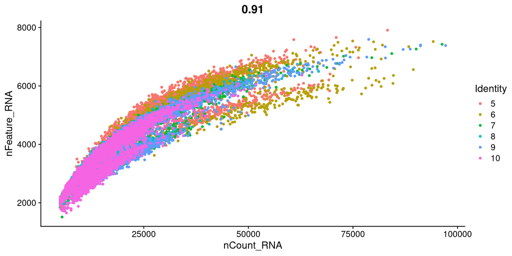

```r
FeatureScatter(seu, feature1 = "nCount_RNA", feature2 = "nFeature_RNA",
               group.by = "sample")
```

## Mitochondrial reads

- Mitochondrial genes’ names start with “mt-”
- Cells with lots of mitochondrial genes are likely damaged and should be removed

```r
rownames(seu)[grepl("^mt-", rownames(seu))]
```

```
 [1] "mt-Nd1"  "mt-Nd2"  "mt-Co1"  "mt-Co2"  "mt-Atp8" "mt-Atp6" "mt-Co3"
 [8] "mt-Nd3"  "mt-Nd4l" "mt-Nd4"  "mt-Nd5"  "mt-Nd6"  "mt-Cytb"
```

```r
seu <- PercentageFeatureSet(seu, pattern = "^mt-", col.name = "percent_mito")
```

## Combined look at mitochondrial reads

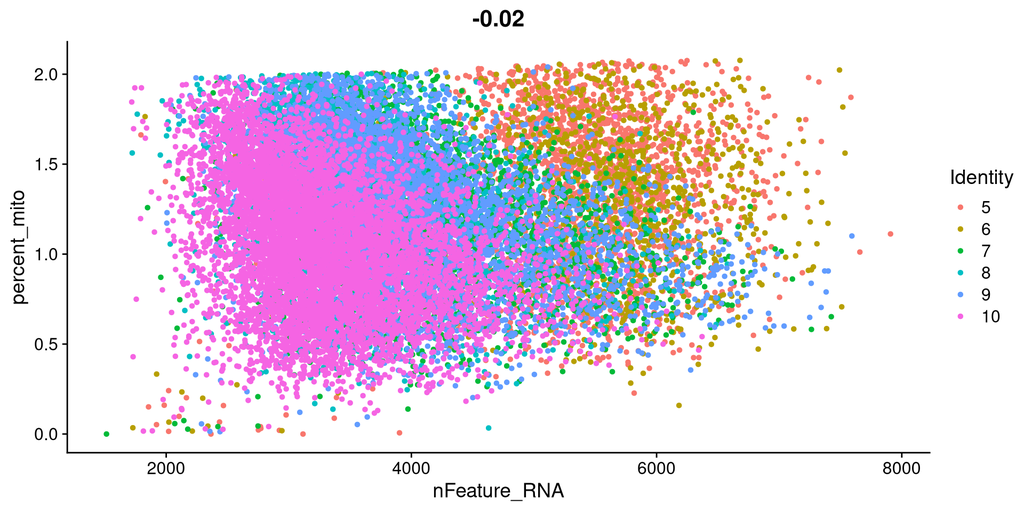

```r
FeatureScatter(seu, feature1 = "nFeature_RNA", feature2 = "percent_mito",
               group.by = "sample")
```

## Filtering to keep quality cells

- We’ll use miQC, a tool packaged with Seurat
- Uses `percent_mito` feature we built
- Also uses `nFeature_RNA`

```r
head(seu@meta.data, n = 3)
```

[output not shown]

```r
seu <- RunMiQC(seu,
          percent.mt = "percent_mito",
          nFeature_RNA = "nFeature_RNA",
          posterior.cutoff = 0.95,      # The probability a cell is part of a compromised distribution. Below the appointed cutoff will be marked to keep.
          model.slot = "flexmix_model" )

table(seu@meta.data$miQC.keep)
```

[output not shown]

## See what changes with your data

```r
seu <- subset(seu, subset = (miQC.keep == "keep"))

table(seu@meta.data$miQC.keep)
```

```
 keep
19586
```

## Doublets

- Unwanted pairs of cells that are analyzed as one
- Don’t cluster with other cells
- Might appear as an intermediate cell type
- Inflate the cell count
- Introduce noise

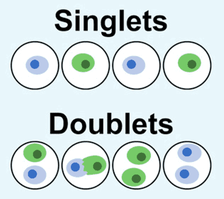

## Filtering cells for doublets

- Doublets can be difficult to detect, but we have tools to find them.
- We’ll use one called `scDblFinder`, which doesn’t work with Seurat objects.
- It works with `SingleCellExperiment` objects.
- Let’s convert our Seurat object to a SCE object.

```r
seu = JoinLayers(seu)

seu = as.SingleCellExperiment(seu)
```

## Find the doublet filtration

```r
seu = scDblFinder(seu)
```

## Converting back to Seurat

```r
seu <- as.Seurat(seu, counts = "counts", data = NULL)

table(seu@meta.data$scDblFinder.class)
```

```
singlet doublet
  17566    2020
```

## Remove cells marked as doublets

```r
seu <- subset(seu, subset = (scDblFinder.class == "singlet"))

table(seu@meta.data$scDblFinder.class)
```

```
singlet doublet
  17566       0
```

## Save your work!!

```r
saveRDS(seu, "/varidata/researchtemp/hpctmp/*your_folder*/scRNA_workshop_2026.rds")
```

## Wrapping up

- Different features of single-cell reads
- “Does the QC make sense?”
- PercentFeatureSet and other Seurat functions to look at features
- Converting between Seurat and SingleCellExperiment objects